# HW4 Time Series

Curtis Zhuang

2021/4/26

#### **Question 1:**

#### Combine the data from the 16 files into a single dataset and plot it.

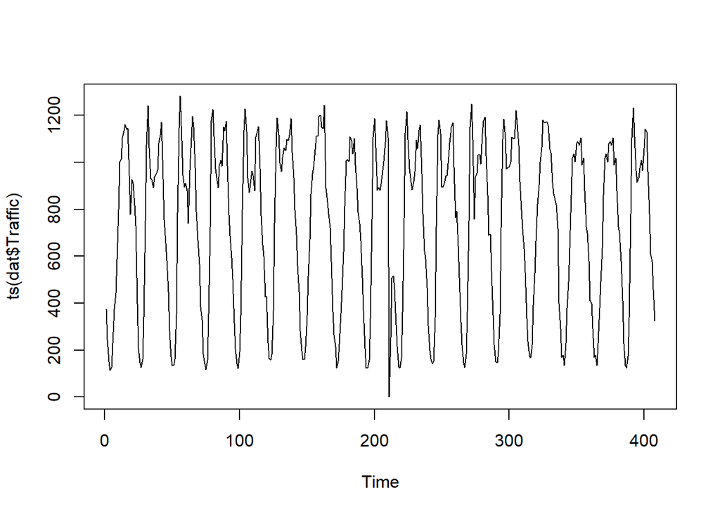

```r
### Convert xls to csv

# dat_path <- paste0(getwd(), '/Traffic Flow Data')
# xls <- dir(path = dat_path, pattern = "xls")
# created <- mapply(convert, xls, gsub("xls", "csv", xls))
# unlink(xls) # delete xlsx files


### read all csv and combine
filenames <- gsub("\\.csv$","", list.files(pattern="\\.csv$"))

for(i in c(1:16)){
  assign(paste0('dat', i), fread(paste(filenames[i], ".csv", sep=""),  select = c(3, 5), blank.lines.skip = TRUE))}

### Combine
dat = rbind(dat2[5:28], dat3[5:28], dat4[5:28], dat5[5:28], dat6[5:28], dat7[5:28], dat8[5:28],
            dat9[5:28], dat10[5:28], dat11[5:28], dat12[5:28], dat13[5:28], dat14[5:28],
            dat15[5:28], dat16[5:28], dat16[5:28], dat1[5:28])

### Rename
names(dat)[names(dat) == "...5"] <- "Traffic"
names(dat)[names(dat) == "...3"] <- "Time"


dat$Traffic <- as.numeric(dat$Traffic)


### plot
plot(ts(dat$Traffic))
```

#### **Question 2:**

#### Split the dataset into a training dataset which includes 6/16/2013 - 6/30/2013 samples and a test dataset which includes 7/1/2013 samples and plot the ACF and PACF.

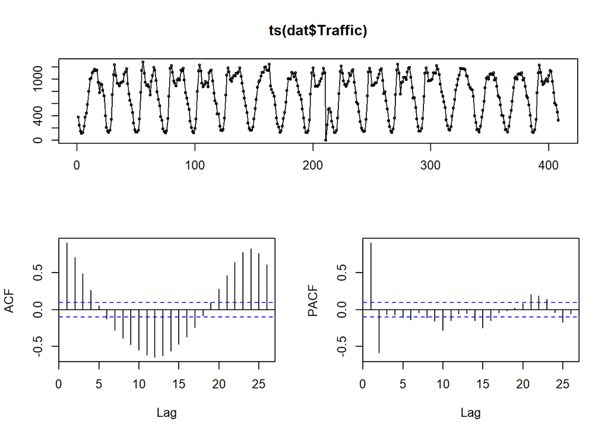

```r
train <- dat[1: 384]

test <- dat[385:408]

### plot
#firstHour <- 24*(as.Date("2013-06-16 01:00:00")-as.Date("2013-01-01 00:00:00"))
#secondHour <- 24*(as.Date("2013-07-01 01:00:00")-as.Date("2013-01-01 00:00:00"))

#train_dt <- ts(train$Traffic, start = c(2013, 6, 16), frequency=24*365)
#test_dt <- ts(train$Traffic, start = c(2013, secondHour), frequency=24*365)

win.graph(width=6, height=6,pointsize=12)
tsdisplay(ts(dat$Traffic))
```

**We see that from PACF there is autocorrelation invovled with p = 2.**

#### **Question 3:**

#### Build an 𝐴𝑅𝐼𝑀𝐴(𝑝,𝑑,𝑞) model using the training dataset and R auto.arima() function. Change the values of 𝑝 and 𝑞 and determine the best model using AICc and BIC values. Do AICc and BIC select the same model as the best model? For each derived model, review the residual plots for the residuals ACF and normality.

```r
### Auto-arima
train_dat <- ts(train$Traffic)
fit<-auto.arima(train_dat, trace = TRUE, lambda = 'auto')
```

```
##
##  Fitting models using approximations to speed things up...
##
##  ARIMA(2,0,2) with non-zero mean : 4947.317
##  ARIMA(0,0,0) with non-zero mean : 5823.273
##  ARIMA(1,0,0) with non-zero mean : 5156.684
##  ARIMA(0,0,1) with non-zero mean : 5420.203
##  ARIMA(0,0,0) with zero mean     : 6440.519
##  ARIMA(1,0,2) with non-zero mean : 5017.846
##  ARIMA(2,0,1) with non-zero mean : 4994.61
##  ARIMA(3,0,2) with non-zero mean : 4949.383
##  ARIMA(2,0,3) with non-zero mean : 4947.115
##  ARIMA(1,0,3) with non-zero mean : 5009.928
##  ARIMA(3,0,3) with non-zero mean : 4950.119
##  ARIMA(2,0,4) with non-zero mean : 4947.347
##  ARIMA(1,0,4) with non-zero mean : 5011.786
##  ARIMA(3,0,4) with non-zero mean : 4951.719
##  ARIMA(2,0,3) with zero mean     : 5046.811
##
##  Now re-fitting the best model(s) without approximations...
##
##  ARIMA(2,0,3) with non-zero mean : 4951.908
##
##  Best model: ARIMA(2,0,3) with non-zero mean
```

```r
print(fit)
```

```
## Series: train_dat
## ARIMA(2,0,3) with non-zero mean
## Box Cox transformation: lambda= 1.043103
##
## Coefficients:
##          ar1      ar2      ma1      ma2      ma3      mean
##       1.8149  -0.8898  -0.5369  -0.2757  -0.1010  952.1442
## s.e.  0.0272   0.0272   0.0580   0.0583   0.0638    9.1916
##
## sigma^2 estimated as 22618:  log likelihood=-2468.81
## AIC=4951.61   AICc=4951.91   BIC=4979.27
```

```r
# Find other p, q
res = data.frame(model=1, AICc=1, BIC=1)
ind = 1


## Based on PACF graph, we will keep p = 2 constant
for (q in seq(0,3)){
  for (d in seq(0,2)){
    m.trial = Arima(train_dat, order=c(2,d,q))
    res[ind, "model"] = paste0(2,d,q, collapse = ",")
    res[ind, "AICc"] = m.trial$aicc
    res[ind, "BIC"] = m.trial$bic
    ind = ind + 1
  }
}

res
```

```
##    model     AICc      BIC
## 1    200 4785.054 4800.751
## 2    210 4827.476 4839.257
## 3    220 4903.340 4915.112
## 4    201 4784.857 4804.451
## 5    211 4775.716 4791.402
## 6    221 4822.603 4838.279
## 7    202 4740.032 4763.513
## 8    212 4775.732 4795.313
## 9    222 4787.703 4807.271
## 10   203 4739.672 4767.028
## 11   213 4829.366 4852.831
## 12   223 4804.186 4827.635
```

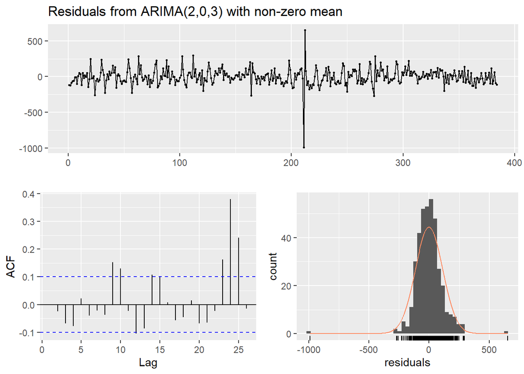

```
##
##  Ljung-Box test
##
## data:  Residuals from ARIMA(2,0,3) with non-zero mean
## Q* = 21.68, df = 4, p-value = 0.000232
##
## Model df: 6.   Total lags used: 10
```

```r
two_three <- Arima(train_dat, order=c(2,0,3))
two_two <- Arima(train_dat, order=c(2,0,2))

checkresiduals(two_three)
```

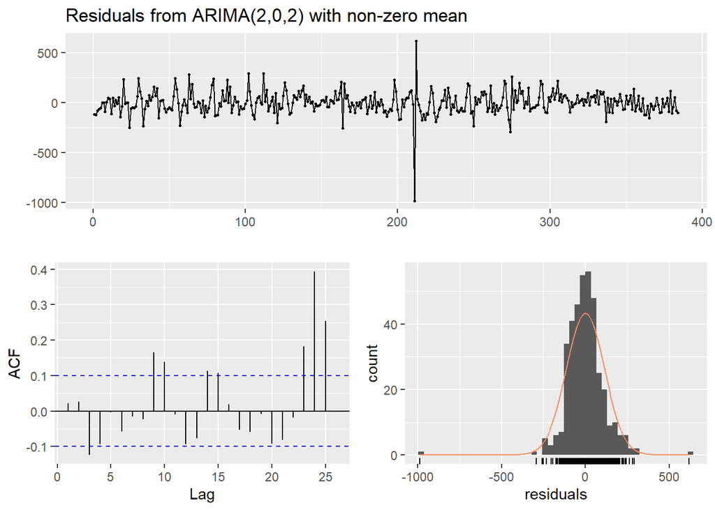

```
##
##  Ljung-Box test
##
## data:  Residuals from ARIMA(2,0,2) with non-zero mean
## Q* = 29.879, df = 5, p-value = 1.558e-05
##
## Model df: 5.   Total lags used: 10
```

```r
checkresiduals(two_two)
```

**Check the residuals for (2,0,3) and (2,0,2), we see that in both cases Ljung-Box gives us a p value smaller than 0.05 which suggests both have a time series component. From the ACF plot, we see that both of them do not have white noise as residuals, thus there may be seasonality involved.**

#### **Question 4:**

#### Build a day of the week seasonal 𝐴𝑅𝐼𝑀𝐴(𝑝,𝑑,𝑞)(𝑃,𝑄,𝐷)𝑠 model using the training dataset and R auto.arima() function.

```r
train_tssea <- ts(train$Traffic, frequency = 7*24)
season_fit<-auto.arima(train_tssea, trace = TRUE)
```

```
##
##  Fitting models using approximations to speed things up...
##
##  ARIMA(2,0,2)(0,1,0)[168] with drift         : 1006.689
##  ARIMA(0,0,0)(0,1,0)[168] with drift         : 1099.162
##  ARIMA(1,0,0)(0,1,0)[168] with drift         : 1005.53
##  ARIMA(0,0,1)(0,1,0)[168] with drift         : 1012.173
##  ARIMA(0,0,0)(0,1,0)[168]                    : 1097.137
##  ARIMA(2,0,0)(0,1,0)[168] with drift         : 1003.061
##  ARIMA(3,0,0)(0,1,0)[168] with drift         : 1005.939
##  ARIMA(2,0,1)(0,1,0)[168] with drift         : 1004.606
##  ARIMA(1,0,1)(0,1,0)[168] with drift         : 1001.641
##  ARIMA(1,0,2)(0,1,0)[168] with drift         : 1003.667
##  ARIMA(0,0,2)(0,1,0)[168] with drift         : 1004.348
##  ARIMA(1,0,1)(0,1,0)[168]                    : 999.5656
##  ARIMA(0,0,1)(0,1,0)[168]                    : 1010.123
##  ARIMA(1,0,0)(0,1,0)[168]                    : 1003.473
##  ARIMA(2,0,1)(0,1,0)[168]                    : 1002.51
##  ARIMA(1,0,2)(0,1,0)[168]                    : 1001.572
##  ARIMA(0,0,2)(0,1,0)[168]                    : 1002.276
##  ARIMA(2,0,0)(0,1,0)[168]                    : 1000.988
##  ARIMA(2,0,2)(0,1,0)[168]                    : 1004.574
##
##  Now re-fitting the best model(s) without approximations...
##
##  ARIMA(1,0,1)(0,1,0)[168]                    : 2686.557
##
##  Best model: ARIMA(1,0,1)(0,1,0)[168]
```

```r
season_fit
```

```
## Series: train_tssea
## ARIMA(1,0,1)(0,1,0)[168]
##
## Coefficients:
##          ar1     ma1
##       0.4230  0.2807
## s.e.  0.1017  0.1108
##
## sigma^2 estimated as 14452:  log likelihood=-1340.22
## AIC=2686.44   AICc=2686.56   BIC=2696.57
```

**Resulting Arima model is (1,0,1)(0,1,0)[168] as frequency is 24 hours * 7 days**

#### **Question 5:**

#### Use the 𝐴𝑅𝐼𝑀𝐴(𝑝,𝑑,𝑞)(𝑃,𝑄,𝐷)𝑠 model from Question 4 to forecast for July 1st (which is a Monday). Plot your result.

```r
prediction_wk <- forecast(season_fit, h = 24)
prediction_wk
```

```
##          Point Forecast      Lo 80     Hi 80       Lo 95     Hi 95
## 3.285714       273.1845  119.12039  427.2486   37.563770  508.8053
## 3.291667       151.7649  -36.62413  340.1540 -136.351268  439.8811
## 3.297619       134.0521  -59.83832  327.9425 -162.477695  430.5819
## 3.303571       170.2518  -24.60645  365.1101 -127.758193  468.2619
## 3.309524       361.7984  166.76750  556.8294   63.524358  660.0725
## 3.315476       763.7607  568.69889  958.8225  465.439404 1062.0820
## 3.321429      1126.3218  931.25443 1321.3891  827.992016 1424.6515
## 3.327381      1216.1361 1021.06777 1411.2044  917.804841 1514.4674
## 3.333333      1098.0576  902.98907 1293.1261  799.726039 1396.3891
## 3.339286       973.0243  777.95582 1168.0929  674.692773 1271.3559
## 3.345238       915.0103  719.94176 1110.0788  616.678714 1213.3419
## 3.351190       884.0044  688.93582 1079.0729  585.672769 1182.3359
## 3.357143       918.0018  722.93330 1113.0704  619.670255 1216.3334
## 3.363095       962.0008  766.93224 1157.0693  663.669192 1260.3324
## 3.369048      1095.0003  899.93179 1290.0689  796.668742 1393.3319
## 3.375000      1059.0001  863.93160 1254.0687  760.668552 1357.3317
## 3.380952      1136.0001  940.93152 1331.0686  837.668472 1434.3316
## 3.386905      1159.0000  963.93148 1354.0686  860.668438 1457.3316
## 3.392857       951.0000  755.93147 1146.0686  652.668423 1249.3316
## 3.398810       781.0000  585.93146  976.0685  482.668417 1079.3316
## 3.404762       623.0000  427.93146  818.0685  324.668414  921.3316
## 3.410714       590.0000  394.93146  785.0685  291.668413  888.3316
## 3.416667       465.0000  269.93146  660.0685  166.668413  763.3316
## 3.422619       305.0000  109.93146  500.0685    6.668413  603.3316
```

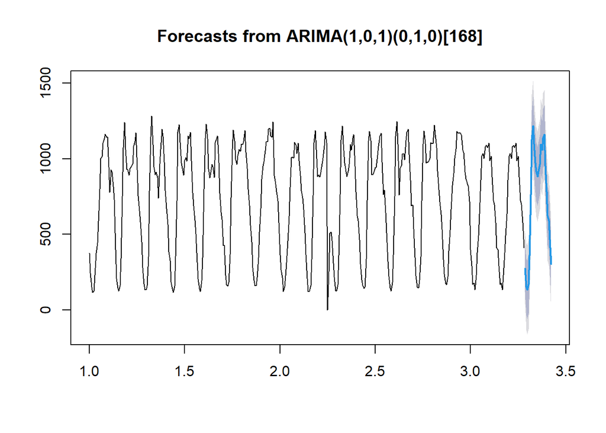

```r
plot(prediction_wk)
```

#### **Question 6:**

#### Build a hour of the day seasonal 𝐴𝑅𝐼𝑀𝐴(𝑝, 𝑑, 𝑞)(𝑃, 𝑄, 𝐷)𝑠model using the training dataset and R auto.arima() function.

```r
train_hr <- ts(train$Traffic, frequency = 24)
hr_fit <- auto.arima(train_hr, trace = TRUE, lambda = 'auto')
```

```
##
##  Fitting models using approximations to speed things up...
##
##  ARIMA(2,0,2)(1,1,1)[24] with drift         : Inf
##  ARIMA(0,0,0)(0,1,0)[24] with drift         : 4440.097
##  ARIMA(1,0,0)(1,1,0)[24] with drift         : 4140.939
##  ARIMA(0,0,1)(0,1,1)[24] with drift         : 4232.52
##  ARIMA(0,0,0)(0,1,0)[24]                    : 4438.078
##  ARIMA(1,0,0)(0,1,0)[24] with drift         : 4189.461
##  ARIMA(1,0,0)(2,1,0)[24] with drift         : 4126.348
##  ARIMA(1,0,0)(2,1,1)[24] with drift         : Inf
##  ARIMA(1,0,0)(1,1,1)[24] with drift         : 4085.015
##  ARIMA(1,0,0)(0,1,1)[24] with drift         : 4153.578
##  ARIMA(1,0,0)(1,1,2)[24] with drift         : Inf
##  ARIMA(1,0,0)(0,1,2)[24] with drift         : Inf
##  ARIMA(1,0,0)(2,1,2)[24] with drift         : Inf
##  ARIMA(0,0,0)(1,1,1)[24] with drift         : 4359.223
##  ARIMA(2,0,0)(1,1,1)[24] with drift         : Inf
##  ARIMA(1,0,1)(1,1,1)[24] with drift         : Inf
##  ARIMA(0,0,1)(1,1,1)[24] with drift         : 4156.965
##  ARIMA(2,0,1)(1,1,1)[24] with drift         : Inf
##  ARIMA(1,0,0)(1,1,1)[24]                    : 4083.027
##  ARIMA(1,0,0)(0,1,1)[24]                    : 4151.536
##  ARIMA(1,0,0)(1,1,0)[24]                    : 4138.928
##  ARIMA(1,0,0)(2,1,1)[24]                    : Inf
##  ARIMA(1,0,0)(1,1,2)[24]                    : Inf
##  ARIMA(1,0,0)(0,1,0)[24]                    : 4187.429
##  ARIMA(1,0,0)(0,1,2)[24]                    : Inf
##  ARIMA(1,0,0)(2,1,0)[24]                    : 4124.326
##  ARIMA(1,0,0)(2,1,2)[24]                    : Inf
##  ARIMA(0,0,0)(1,1,1)[24]                    : 4357.749
##  ARIMA(2,0,0)(1,1,1)[24]                    : Inf
##  ARIMA(1,0,1)(1,1,1)[24]                    : Inf
##  ARIMA(0,0,1)(1,1,1)[24]                    : 4155.26
##  ARIMA(2,0,1)(1,1,1)[24]                    : Inf
##
##  Now re-fitting the best model(s) without approximations...
##
##  ARIMA(1,0,0)(1,1,1)[24]                    : Inf
##  ARIMA(1,0,0)(1,1,1)[24] with drift         : Inf
##  ARIMA(1,0,0)(2,1,0)[24]                    : 4389.186
##
##  Best model: ARIMA(1,0,0)(2,1,0)[24]
```

```r
hr_fit
```

```
## Series: train_hr
## ARIMA(1,0,0)(2,1,0)[24]
## Box Cox transformation: lambda= 0.9955707
##
## Coefficients:
##          ar1     sar1     sar2
##       0.7454  -0.3378  -0.2697
## s.e.  0.0356   0.0547   0.0522
##
## sigma^2 estimated as 11192:  log likelihood=-2190.54
## AIC=4389.07   AICc=4389.19   BIC=4404.62
```

**Resulting Arima model is (1,0,0)(2,1,0)[24] as frequency is 24 hours * 1 day**

#### **Question 7:**

#### Use the 𝐴𝑅𝐼𝑀𝐴(𝑝, 𝑑, 𝑞)(𝑃, 𝑄, 𝐷)𝑠 model from Question 6 to forecast for July 1st (which is a Monday). Plot your result.

```r
prediction_day <- forecast(hr_fit, h = 24)
prediction_day
```

```
##          Point Forecast     Lo 80     Hi 80      Lo 95     Hi 95
## 17.00000       341.5954 202.61715  480.8320  129.20662  554.6159
## 17.04167       248.2847  75.37650  421.7826  -15.35481  513.7668
## 17.08333       148.3992 -39.78908  338.0506 -139.72848  438.6649
## 17.12500       158.4677 -38.24502  356.7016 -142.68156  461.8665
## 17.16667       145.1050 -56.09058  347.8819 -163.04314  455.4708
## 17.20833       263.4344  58.58481  469.0899  -48.89133  578.1354
## 17.25000       412.0103 205.13724  619.3661   95.97444  729.2669
## 17.29167       533.5001 325.55160  741.8179  215.69387  852.2055
## 17.33333       681.8521 473.20315  890.7889  362.90775 1001.4852
## 17.37500       868.7356 659.59029 1078.1064  548.98962 1189.0162
## 17.41667      1011.5497 802.11417 1221.1788  691.34043 1332.2163
## 17.45833      1042.2305 832.69151 1251.9576  721.85966 1363.0453
## 17.50000      1048.8128 839.22696 1258.5855  728.36968 1369.6971
## 17.54167      1102.8488 893.18874 1312.6867  782.28688 1423.8300
## 17.58333      1109.7257 900.04675 1319.5813  789.13430 1430.7337
## 17.62500      1099.3991 889.72287 1309.2536  778.81281 1420.4060
## 17.66667      1118.9283 909.23016 1328.8017  798.30670 1439.9631
## 17.70833      1006.6061 797.01517 1216.3919  686.15989 1327.5127
## 17.75000      1024.2699 814.65969 1234.0715  703.79222 1345.1998
## 17.79167       888.2884 678.82680 1097.9711  568.05591 1209.0447
## 17.83333       763.4470 554.14704  973.0047  443.48569 1084.0221
## 17.87500       735.3971 526.13756  944.9243  415.50453 1055.9282
## 17.91667       643.9046 434.79167  853.3243  324.26477  964.2810
## 17.95833       494.2217 285.41462  703.4327  175.13505  814.3007
```

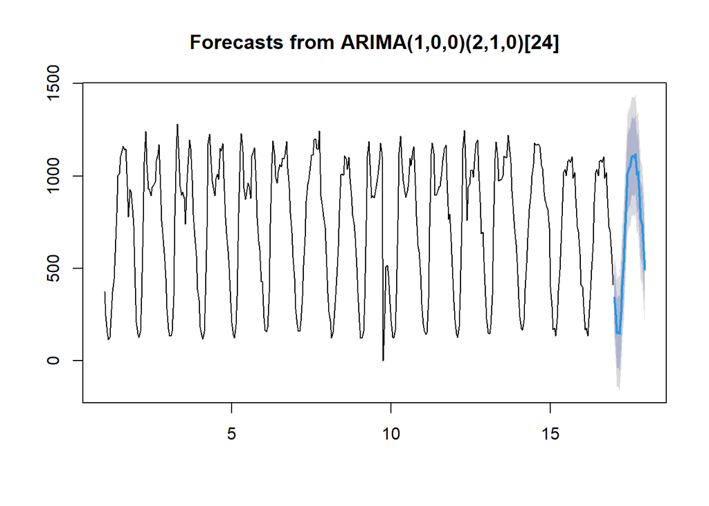

```r
plot(prediction_day)
```

#### **Question 8:**

#### Compare the forecast of the models from Questions 5 and 7 for July 1 8:00, 9:00, 17:00 and 18:00, which model is better (Questions 4 or 6)?

```r
Jul <- data.frame(Time = test$Time[c(8, 9, 17, 18)],
                  Week = prediction_wk$mean[c(8, 9, 17, 18)],
                  Day = prediction_day$mean[c(8, 9, 17, 18)],
                  Actual = test$Traffic[c(8, 9, 17, 18)])

Jul
```

```
##    Time     Week       Day Actual
## 1 08:00 1216.136  533.5001   1233
## 2 09:00 1098.058  681.8521   1110
## 3 17:00 1136.000 1118.9283   1142
## 4 18:00 1159.000 1006.6061   1129
```

**Based on comparison I think the model from Q4 which is the model with week as frequency is better.**